# Practical Machine Learning

Saurabh Thakur

August 6, 2018

**Loading the libraries before hand.**

```r
library(caret, quietly = TRUE)
```

```r
library(knitr, quietly = TRUE)
library(rpart, quietly = TRUE)
library(rpart.plot, quietly = TRUE)
#library(rattle)
library(randomForest, quietly = TRUE)
library(corrplot, quietly = TRUE)
```

**Setting up the working directory.**

```r
setwd("D:/R/assignments/machine learning/scripts")
```

**Set the urls for the data and the file names for the destination.**

```r
train_url <- "https://d396qusza40orc.cloudfront.net/predmachlearn/pml-training.csv"
test_url <- "https://d396qusza40orc.cloudfront.net/predmachlearn/pml-testing.csv"
#
train_file <- "pml-training.csv"
test_file <- "pml-testing.csv"
```

**Check if the file exists in the local drive, if not then download them from the links and once downloaded, then read the files to R.**

```r
if(!file.exists(train_file)){
  download.file(train_url, destfile = train_file)
}
training_data <- read.csv(train_file)
#
if(!file.exists(test_file)){
  download.file(test_url, destfile = test_file)
}
test_data <- read.csv(test_file)
```

**Create the split set for creating the test set and the training set.**

```r
inTrain <- createDataPartition(training_data$classe,
                               p=0.7,
                               list = FALSE)
TrainSet <- training_data[inTrain,]
TestSet <- training_data[-inTrain,]
#
dim(TrainSet)
```

```
## [1] 13737   160
```

```r
dim(TestSet)
```

```
## [1] 5885  160
```

## Data Clean up and Exploratory analysis.

- Here we are removing the Near Zero Value columns. This will give us a cleaner data set with reduced noise.
- Then we are removing the columns which are mostly containing “NA” values. This is achived by checking if the mean of the column is nearing 1.
- The last step is to remove the first 5 columns with identifying data.

```r
NZV <- nearZeroVar(TrainSet)
TrainSet <- TrainSet[, -NZV]
TestSet  <- TestSet[, -NZV]
dim(TrainSet)
```

```
## [1] 13737   105
```

```r
dim(TestSet)
```

```
## [1] 5885  105
```

```r
# remove variables that are mostly NA
mostlyNA    <- sapply(TrainSet, function(x) mean(is.na(x))) > 0.95
TrainSet <- TrainSet[, mostlyNA==FALSE]
TestSet  <- TestSet[, mostlyNA==FALSE]
dim(TestSet)
```

```
## [1] 5885   59
```

```r
dim(TrainSet)
```

```
## [1] 13737    59
```

```r
#
# remove identification only variables (columns 1 to 5)
TrainSet <- TrainSet[, -(1:5)]
TestSet  <- TestSet[, -(1:5)]
dim(TrainSet)
```

```
## [1] 13737    54
```

```r
dim(TestSet)
```

```
## [1] 5885   54
```

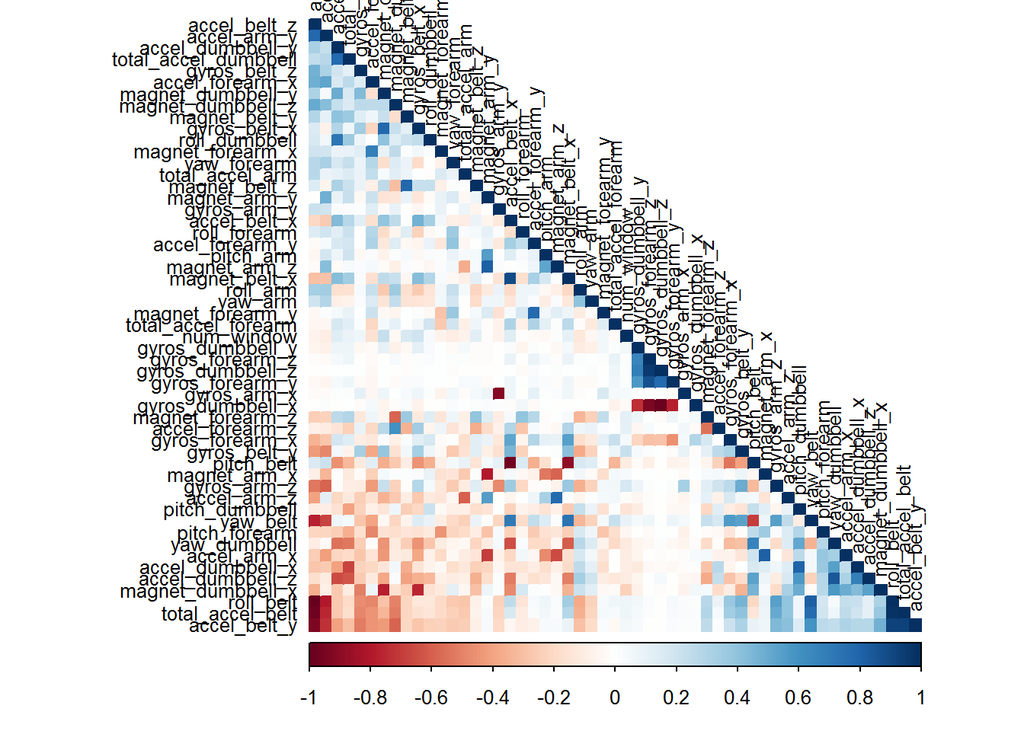

```r
#
#corelation analysis graph
#
corMatrix <- cor(TrainSet[, -54])
corrplot(corMatrix, order = "FPC", method = "color", type = "lower",
         tl.cex = 0.8, tl.col = rgb(0, 0, 0))
```

The resultant data set has 54 columns only.

## Prediction Model Building

Three popular methods will be applied to model the regressions (in the Train dataset) and the best one (with higher accuracy when applied to the Test dataset) will be used for the quiz predictions.

In this course we have gone thru the following methods.

- Random Forests
- Decision Tree and
- Generalized Boosted Model

A Confusion Matrix is plotted at the end of each analysis to better visualize the accuracy of the models.

### **a. Random Forests**

```r
# model fit
set.seed(301)
controlRF <- trainControl(method="cv", number=3, verboseIter=FALSE)
modFitRandForest <- train(classe ~ ., data=TrainSet, method="rf",
                          trControl=controlRF)
modFitRandForest$finalModel
```

```
##
## Call:
##  randomForest(x = x, y = y, mtry = param$mtry)
##                Type of random forest: classification
##                      Number of trees: 500
## No. of variables tried at each split: 27
##
##         OOB estimate of  error rate: 0.21%
## Confusion matrix:
##      A    B    C    D    E  class.error
## A 3904    1    0    0    1 0.0005120328
## B    4 2650    3    1    0 0.0030097818
## C    0    5 2391    0    0 0.0020868114
## D    0    0   13 2239    0 0.0057726465
## E    0    0    0    1 2524 0.0003960396
```

Prediction on the test dataset.

```r
# prediction on Test dataset
predictRandForest <- predict(modFitRandForest, newdata=TestSet)
confMatRandForest <- confusionMatrix(predictRandForest, TestSet$classe)
confMatRandForest
```

```
## Confusion Matrix and Statistics
##
##           Reference
## Prediction    A    B    C    D    E
##          A 1674    4    0    0    0
##          B    0 1133    1    0    0
##          C    0    2 1025    2    0
##          D    0    0    0  961    0
##          E    0    0    0    1 1082
##
## Overall Statistics
##
##                Accuracy : 0.9983
##                  95% CI : (0.9969, 0.9992)
##     No Information Rate : 0.2845
##     P-Value [Acc > NIR] : < 2.2e-16
##
##                   Kappa : 0.9979
##  Mcnemar's Test P-Value : NA
##
## Statistics by Class:
##
##                      Class: A Class: B Class: C Class: D Class: E
## Sensitivity            1.0000   0.9947   0.9990   0.9969   1.0000
## Specificity            0.9991   0.9998   0.9992   1.0000   0.9998
## Pos Pred Value         0.9976   0.9991   0.9961   1.0000   0.9991
## Neg Pred Value         1.0000   0.9987   0.9998   0.9994   1.0000
## Prevalence             0.2845   0.1935   0.1743   0.1638   0.1839
## Detection Rate         0.2845   0.1925   0.1742   0.1633   0.1839
## Detection Prevalence   0.2851   0.1927   0.1749   0.1633   0.1840
## Balanced Accuracy      0.9995   0.9973   0.9991   0.9984   0.9999
```

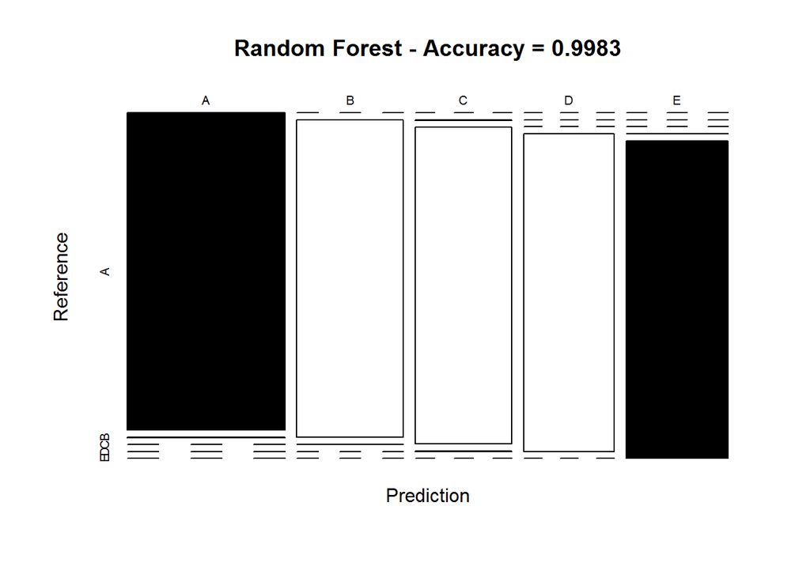

```r
# plot matrix results
plot(confMatRandForest$table, col = confMatRandForest$byClass,
     main = paste("Random Forest - Accuracy =",
                  round(confMatRandForest$overall['Accuracy'], 4)))
```

### **b. Decision Tree**

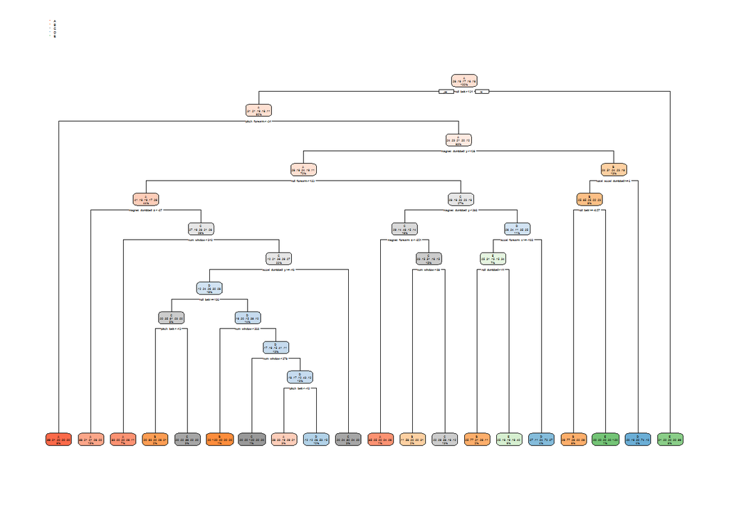

```r
# model fit
set.seed(301)
modFitDecTree <- rpart(classe ~ ., data=TrainSet, method="class")
#fancyRpartPlot(modFitDecTree)
rpart.plot(modFitDecTree)
```

```r
#prediction on the test data
predictDecTree <- predict(modFitDecTree, newdata=TestSet, type="class")
confMatDecTree <- confusionMatrix(predictDecTree, TestSet$classe)
confMatDecTree
```

```
## Confusion Matrix and Statistics
##
##           Reference
## Prediction    A    B    C    D    E
##          A 1498  246   37   96   84
##          B   36  605   42   32   93
##          C   22   58  811  139   74
##          D   96  160   61  643  133
##          E   22   70   75   54  698
##
## Overall Statistics
##
##                Accuracy : 0.723
##                  95% CI : (0.7114, 0.7344)
##     No Information Rate : 0.2845
##     P-Value [Acc > NIR] : < 2.2e-16
##
##                   Kappa : 0.648
##  Mcnemar's Test P-Value : < 2.2e-16
##
## Statistics by Class:
##
##                      Class: A Class: B Class: C Class: D Class: E
## Sensitivity            0.8949   0.5312   0.7904   0.6670   0.6451
## Specificity            0.8900   0.9572   0.9397   0.9086   0.9540
## Pos Pred Value         0.7639   0.7488   0.7346   0.5883   0.7595
## Neg Pred Value         0.9551   0.8948   0.9550   0.9330   0.9227
## Prevalence             0.2845   0.1935   0.1743   0.1638   0.1839
## Detection Rate         0.2545   0.1028   0.1378   0.1093   0.1186
## Detection Prevalence   0.3332   0.1373   0.1876   0.1857   0.1562
## Balanced Accuracy      0.8925   0.7442   0.8651   0.7878   0.7995
```

### Plot Matrix Results

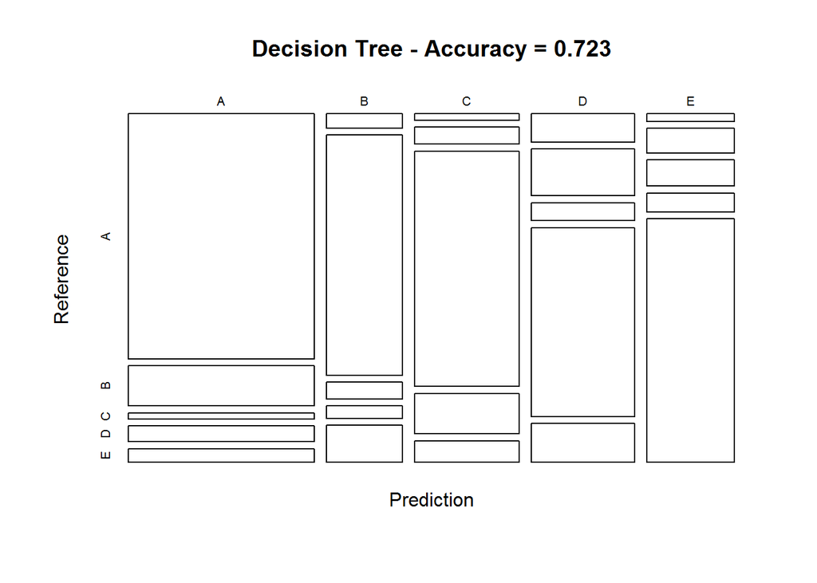

```r
plot(confMatDecTree$table, col = confMatDecTree$byClass,
     main = paste("Decision Tree - Accuracy =",
                  round(confMatDecTree$overall['Accuracy'], 4)))
```

### **c. Generalized Boosted Model (GBM)**

```r
# model fit
set.seed(301)
controlGBM <- trainControl(method = "repeatedcv", number = 5, repeats = 1)
modFitGBM  <- train(classe ~ ., data=TrainSet, method = "gbm",
                    trControl = controlGBM, verbose = FALSE)
modFitGBM$finalModel
```

```
## A gradient boosted model with multinomial loss function.
## 150 iterations were performed.
## There were 53 predictors of which 41 had non-zero influence.
```

### Confusion Matrix

```r
# prediction on Test dataset
predictGBM <- predict(modFitGBM, newdata=TestSet)
confMatGBM <- confusionMatrix(predictGBM, TestSet$classe)
confMatGBM
```

```
## Confusion Matrix and Statistics
##
##           Reference
## Prediction    A    B    C    D    E
##          A 1665    9    0    2    0
##          B    8 1116    8    1    1
##          C    0   11 1012    9    3
##          D    1    3    4  950    5
##          E    0    0    2    2 1073
##
## Overall Statistics
##
##                Accuracy : 0.9883
##                  95% CI : (0.9852, 0.9909)
##     No Information Rate : 0.2845
##     P-Value [Acc > NIR] : < 2.2e-16
##
##                   Kappa : 0.9852
##  Mcnemar's Test P-Value : NA
##
## Statistics by Class:
##
##                      Class: A Class: B Class: C Class: D Class: E
## Sensitivity            0.9946   0.9798   0.9864   0.9855   0.9917
## Specificity            0.9974   0.9962   0.9953   0.9974   0.9992
## Pos Pred Value         0.9934   0.9841   0.9778   0.9865   0.9963
## Neg Pred Value         0.9979   0.9952   0.9971   0.9972   0.9981
## Prevalence             0.2845   0.1935   0.1743   0.1638   0.1839
## Detection Rate         0.2829   0.1896   0.1720   0.1614   0.1823
## Detection Prevalence   0.2848   0.1927   0.1759   0.1636   0.1830
## Balanced Accuracy      0.9960   0.9880   0.9908   0.9914   0.9954
```

### Plot GBM Results

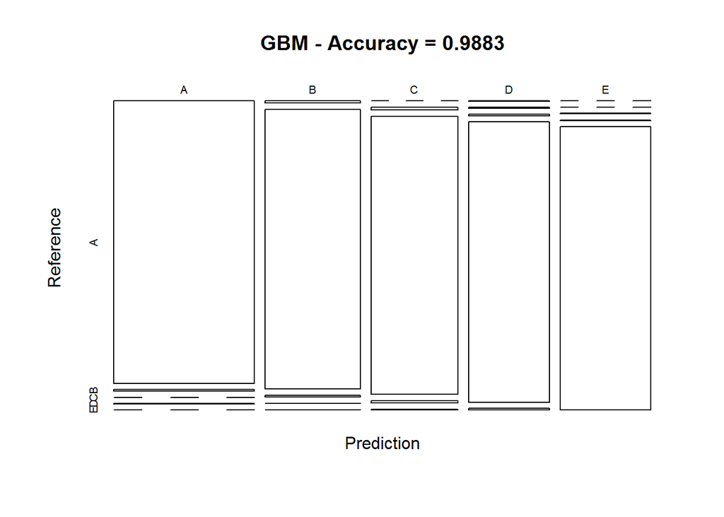

```r
# plot matrix results
plot(confMatGBM$table, col = confMatGBM$byClass,
     main = paste("GBM - Accuracy =",
                  round(confMatGBM$overall['Accuracy'], 4)))
```

### The accuracy of the 3 regression modeling methods above are as follows

| Prediction Model | Accuracy |
| --- | --- |
| Random Forest | 0.9983 |
| Decision Tree | 0.723 |
| GBM | 0.9883 |

## Applying the selected Model to the Test Data

From the table above we see that in this case the *Random Forest model* has the most accuracy. Therefore, in this case, we will be applying the **Random Forest model** to predict the 20 quiz results **pml-testing.csv** as shown below.

```r
predictTEST <- predict(modFitRandForest, newdata=test_data)
predictTEST
```

```
##  [1] B A B A A E D B A A B C B A E E A B B B
## Levels: A B C D E
```

*The Prediction model behaves accurately as all the 20 predictions are correct.*